# kmeans Clustering Exercise

Bert Gollnick

October 2, 2018

```r
suppressPackageStartupMessages(library(dplyr))
suppressPackageStartupMessages(library(ggplot2))
suppressPackageStartupMessages(library(stats))
suppressPackageStartupMessages(library(caret))
```

# 1 Introduction

We will work on a dataset on Pulsar candidates. This data was collected during “High Time Resolution Universe Survey (South)”.

Some candidates were later confirmed Pulsars, the other could not be confirmed. This is supervised learning. Assume we don’t know the true values, because this is the purpose of clustering - to find relationships that were not known before.

Here we will use the “true” values to assess how well our clustering works.

# 2 Data Understanding

Data and description of data is found [here](https://archive.ics.uci.edu/ml/datasets/HTRU2).

HTRU2 is a data set which describes a sample of pulsar candidates collected during the High Time Resolution Universe Survey (South) [1].

Pulsars are a rare type of Neutron star that produce radio emission detectable here on Earth. They are of considerable scientific interest as probes of space-time, the inter-stellar medium, and states of matter (see [2] for more uses). c As pulsars rotate, their emission beam sweeps across the sky, and when this crosses our line of sight, produces a detectable pattern of broadband radio emission. As pulsars rotate rapidly, this pattern repeats periodially. Thus pulsar search involves looking for periodic radio signals with large radio telescopes.

Each pulsar produces a slightly different emission pattern, which varies slightly with each rotation (see [2] for an introduction to pulsar astrophysics to find out why). Thus a potential signal detection known as a ‘candidate’, is averaged over many rotations of the pulsar, as determined by the length of an observation. In the absence of additional info, each candidate could potentially describe a real pulsar. However in practice almost all detections are caused by radio frequency interference (RFI) and noise, making legitimate signals hard to find.

Machine learning tools are now being used to automatically label pulsar candidates to facilitate rapid analysis. Classification systems in particular are being widely adopted, (see [4,5,6,7,8,9]) which treat the candidate data sets as binary classification problems. Here the legitimate pulsar examples are a minority positive class, and spurious examples the majority negative class. At present multi-class labels are unavailable, given the costs associated with data annotation.

Our attributes are:

1. Mean of the integrated profile.
2. Standard deviation of the integrated profile.
3. Excess kurtosis of the integrated profile.
4. Skewness of the integrated profile.
5. Mean of the DM-SNR curve.
6. Standard deviation of the DM-SNR curve.
7. Excess kurtosis of the DM-SNR curve.
8. Skewness of the DM-SNR curve.
9. Class (target variable)

# 3 Data Preparation

## 3.1 Data Download

First we download the data.

```r
# if file does not exist, download it first
file_path <- "./data/HTRU2.zip"
if (!file.exists(file_path)) {
  dir.create("./data")
  url <- "https://archive.ics.uci.edu/ml/machine-learning-databases/00372/HTRU2.zip"
  download.file(url = url,
                destfile = file_path)
}

# unzip the file
unzip(zipfile = file_path, exdir = "./data")
```

## 3.2 Data Import

Import the data and assign it to a dataframe, called “df_raw”.

```r
df_raw <- read.csv('./data/HTRU_2.csv', header=F)
df_raw %>% head()
```

```
##          V1       V2          V3         V4       V5       V6        V7
## 1 140.56250 55.68378 -0.23457141 -0.6996484 3.199833 19.11043  7.975532
## 2 102.50781 58.88243  0.46531815 -0.5150879 1.677258 14.86015 10.576487
## 3 103.01562 39.34165  0.32332837  1.0511644 3.121237 21.74467  7.735822
## 4 136.75000 57.17845 -0.06841464 -0.6362384 3.642977 20.95928  6.896499
## 5  88.72656 40.67223  0.60086608  1.1234917 1.178930 11.46872 14.269573
## 6  93.57031 46.69811  0.53190485  0.4167211 1.636288 14.54507 10.621748
##          V8 V9
## 1  74.24222  0
## 2 127.39358  0
## 3  63.17191  0
## 4  53.59366  0
## 5 252.56731  0
## 6 131.39400  0
```

Assign the right column names.

Please use these names:

“Profile_mean”, “Profile_stdev”, “Profile_skewness”, “Profile_kurtosis”, “DM_mean”, “DM_stdev”, “DM_skewness”, “DM_kurtosis”, “class”

```r
cnames <- c("Profile_mean", "Profile_stdev", "Profile_skewness", "Profile_kurtosis", "DM_mean", "DM_stdev", "DM_skewness", "DM_kurtosis", "class")
colnames(df_raw) <- cnames
df_raw %>% head()
```

```
##   Profile_mean Profile_stdev Profile_skewness Profile_kurtosis  DM_mean
## 1    140.56250      55.68378      -0.23457141       -0.6996484 3.199833
## 2    102.50781      58.88243       0.46531815       -0.5150879 1.677258
## 3    103.01562      39.34165       0.32332837        1.0511644 3.121237
## 4    136.75000      57.17845      -0.06841464       -0.6362384 3.642977
## 5     88.72656      40.67223       0.60086608        1.1234917 1.178930
## 6     93.57031      46.69811       0.53190485        0.4167211 1.636288
##   DM_stdev DM_skewness DM_kurtosis class
## 1 19.11043    7.975532    74.24222     0
## 2 14.86015   10.576487   127.39358     0
## 3 21.74467    7.735822    63.17191     0
## 4 20.95928    6.896499    53.59366     0
## 5 11.46872   14.269573   252.56731     0
## 6 14.54507   10.621748   131.39400     0
```

## 3.3 Data Understanding

Find out if there are NA to be handled!

```r
summary(df_raw)
```

```
##   Profile_mean     Profile_stdev   Profile_skewness  Profile_kurtosis
##  Min.   :  5.812   Min.   :24.77   Min.   :-1.8760   Min.   :-1.7919
##  1st Qu.:100.930   1st Qu.:42.38   1st Qu.: 0.0271   1st Qu.:-0.1886
##  Median :115.078   Median :46.95   Median : 0.2232   Median : 0.1987
##  Mean   :111.080   Mean   :46.55   Mean   : 0.4779   Mean   : 1.7703
##  3rd Qu.:127.086   3rd Qu.:51.02   3rd Qu.: 0.4733   3rd Qu.: 0.9278
##  Max.   :192.617   Max.   :98.78   Max.   : 8.0695   Max.   :68.1016
##     DM_mean            DM_stdev       DM_skewness      DM_kurtosis
##  Min.   :  0.2132   Min.   :  7.37   Min.   :-3.139   Min.   :  -1.977
##  1st Qu.:  1.9231   1st Qu.: 14.44   1st Qu.: 5.782   1st Qu.:  34.961
##  Median :  2.8018   Median : 18.46   Median : 8.434   Median :  83.065
##  Mean   : 12.6144   Mean   : 26.33   Mean   : 8.304   Mean   : 104.858
##  3rd Qu.:  5.4643   3rd Qu.: 28.43   3rd Qu.:10.703   3rd Qu.: 139.309
##  Max.   :223.3921   Max.   :110.64   Max.   :34.540   Max.   :1191.001
##      class
##  Min.   :0.00000
##  1st Qu.:0.00000
##  Median :0.00000
##  Mean   :0.09157
##  3rd Qu.:0.00000
##  Max.   :1.00000
```

There are no NA’s that need to be handled.

How many legitimate pulsars (class 1) and how many spurious results (class 0) are there?

```r
table(df_raw$class)
```

```
##
##     0     1
## 16259  1639
```

```r
16259+1639 ==length(df_raw$class)
```

```
## [1] TRUE
```

## 3.4 Baseline Classifier

Assume you want to create a classifier. What is your baseline classification accuracy?

```r
table(df_raw$class)[1]/length(df_raw$class)
```

```
##         0
## 0.9084255
```

## 3.5 Data Manipulation

In clustering a distance is measured. Due to this, it is important to apply scaling to the data.

```r
df_scaled <- df_raw %>%
  scale()
```

# 4 Model

In this chapter you will create a clustering model and evaluate it afterwards.

## 4.1 Model Creation

Please create a clustering model based on kmeans-algorithm. With kmeans you need to assign how many clusters should be defined. Please select a reasonable number of clusters.

```r
set.seed(123)
k_max <- 9
within_cluster_sum_square <- tibble(k=1: k_max,
                                    wcss =NA)

for (i in within_cluster_sum_square$k){
  within_cluster_sum_square$wcss[i] <- kmeans(x=df_scaled, centers = i, nstart=10)$tot.withinss
}
```

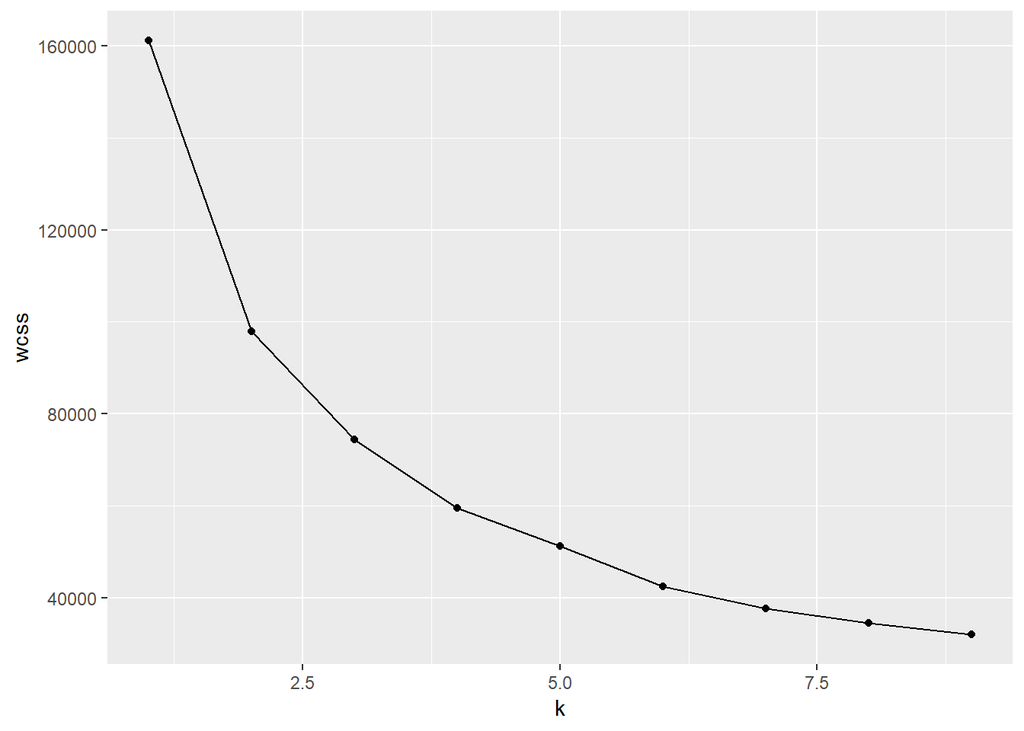

```r
g <- ggplot(within_cluster_sum_square, aes(k, wcss))
g <- g+ geom_line()
g <- g+ geom_point()
g
```

```r
set.seed(123)
mod_cluster <- kmeans(x=df_scaled, centers = 2)
```

```r
df_raw$cluster <- mod_cluster$cluster-1
df_raw$cluster <- ifelse(df_raw$cluster ==1, 0, 1)
```

x specifies the data. k specifies the number of clusters.